# Orbits

[figure not shown]

The first artifical satellite [sputnik](https://en.wikipedia.org/wiki/Sputnik_1)

### Rocket Launch

Consider a rocket launched from the surface of the earth with velocity $v_{0}$, if it's height above the ground is $x$ then

$\frac{dv}{dt}=\frac{-GM_{E}}{(R_{E}+x)^{2}}$

$\frac{dv}{dx}\frac{dx}{dt}=v\frac{dv}{dx}=\frac{-GM_{E}}{(R_{E}+x)^{2}}$

$\int^{v}_{v_{0}}v\,dv=\int^{x}_{0}\frac{-GM_{E}}{(R_{E}+x)^{2}}\,dx$

$\frac{1}{2}(v^{2}-v_{0}^2)=\frac{GM_{E}}{R_{E}+x}-\frac{GM_{E}}{R_{E}}$

$v^{2}=v_{0}^2+2(\frac{GM_{E}}{R_{E}+x}-\frac{GM_{E}}{R_{E}})$

We can see whether or not the rocket achieves escape velocity by considering the limit as $x\to\infty$

### Escape Velocity

$v^{2}=v_{0}^2+2(\frac{GM_{E}}{R_{E}+x}-\frac{GM_{E}}{R_{E}})$

For the object to escape

$v_{0}\geq \sqrt{\frac{2GM_{E}}{R_{E}}}$

$M_{E}=5.98\times10^{24}\mathrm{kg}$

$R_{E}=6380\mathrm{km}$

$G=6.67\times10^{-11}\mathrm{Nm^{2}kg^{-2}}$

$\to v_{0}=11,200\mathrm{ms^{-1}}$

### Satellites

For a circular orbit a satellite of mass $m$ must have a velocity such that the gravitational acceleration is the same as the centripetal acceleration. In this equation r is the distance from the satellite to the center of the earth.

$G\frac{mM_{E}}{r^{2}}=\frac{mv^{2}}{r}$

$v_{circular}=\sqrt{\frac{GM_{E}}{r}}$

In the video below, from Professor Mike Zingale's courses [here](https://zingale.github.io/astro_animations/) you see the orbits of two planets around a star, neglecting the gravitational force between the planets themselves. This is useful for demonstrating Kepler's third law. We work in units of AU, years, and solar masses. The semi-major axes are picked such that one planet has an orbital period of 1 year and the other of 2 years.

```python
from IPython.display import HTML

HTML("""
<div align="middle">
<video width="80%" controls>
      <source src="Videos/orbit2.mp4" type="video/mp4">
</video></div>""")
```

[video not shown]

### Geosynchronous satellite

For a satellite to have a fixed position above the Earth's surface it must have the same **angular** velocity as a point on the Earth's surface. Another way of looking at this is that the satellite must take exactly one day to complete it's path.

$\frac{2\pi r}{v}$ = 1 day = 86,400 s

Using the equation for the velocity $v=\sqrt{\frac{GM_{E}}{r}}$

$2\pi\frac{r^{3/2}}{\sqrt{GM_{E}}}$ = 86,400 s

$r=(86,400\frac{\sqrt{GM_{E}}}{2\pi})^{2/3}=4.23\times10^{7}\,\mathrm{m}=42,300\,\mathrm{km}$

(36,000 km above surface)

Mass of Earth $M_{E}=5.9742\times10^{24}\,\mathrm{kg}$

Gravitational Constant $G=6.67\times10^{-11}\,\mathrm{Nm^{2}kg{-2}}$

### GPS

[figure not shown]

[GPS](https://en.wikipedia.org/wiki/Global_Positioning_System) satellites are essentially extremely accurate clocks that continually broadcast their position and the time, which an Earth based receiver can use to calculate it's own position, so long as it can receive at least 4 signals. It is not desirable for GPS satellites to be in geostationary orbits.

A GPS satellite orbits about 20,200 km above the surface of the Earth (or at a radius of 26,600 km from the center of the Earth.)

**How many times a day do the GPS Satellites go round the Earth?**

$v=\sqrt{\frac{GM_{E}}{r}}$

Mass of Earth $M_{E}=5.9742\times10^{24}\,\mathrm{kg}$

Gravitational Constant $G=6.67\times10^{-11}\,\mathrm{Nm^{2}kg^{-2}}$

### GPS problem solution

Number of seconds for a GPS satellite to go round the Earth $\frac{2\pi r}{v}=2\pi\frac{r^{3/2}}{\sqrt{GM_{E}}}=2\pi\frac{(2.66\times10^{7})^{3/2}}{\sqrt{6.67\times10^{-11}\times5.9742\times10^{24}}}=43,200 s$

Times round the earth in a day = Seconds in one day/Number of seconds for a satellite to go round the Earth

Seconds in one day = $24\times60\times60=86400$

Times round the earth in one day $\approx 2$

$v=3870\mathrm{m/s}$

This is fast enough that the clock on a GPS satellite is slightly slower than one on Earth because of [special relativity](https://en.wikipedia.org/wiki/Special_relativity). However due to [general relativity](https://en.wikipedia.org/wiki/General_relativity) the difference in the gravitational force between the surface of the Earth and the height of the satellite causes the clock to go faster than on one Earth. These two effects need to be taken in to account for the GPS system to work.

### Elliptical Orbits

Recall from the last lecture that the escape velocity is

$v_{E}=\sqrt{\frac{2GM_{E}}{R_{E}}}$

Compare this to

$v=\sqrt{\frac{GM_{E}}{r}}$

and $r \gt R_{E}$

So there are velocities above the velocity required for a circular velocity, but less than escape velocity. These lead to elliptical orbits.

### Elliptical Orbits:

So there are velocities above the velocity required for a circular velocity, but less than escape velocity. These lead to elliptical orbits.

A simple animation that shows a projectile with increasing horizontal velocity, working up to the circular velocity. (This script uses the image earth.png; image credit: NASA/Apollo 17)

Credit: [Prof. Zingale](https://zingale.github.io/astro_animations/)

```python
from IPython.display import HTML

HTML("""
<div align="middle">
<video width="80%" controls>
      <source src="Videos/achieveorbit.mp4 " type="video/mp4">
</video></div>""")
```

[video not shown]

### Circular Vs Escape Velocity

A simple animation showing how the orbit of a projectile around Earth changes as we increase the change the tangential velocity from less than the circular velocity to greater than the escape velocity. (This script uses the image earth.png; image credit: NASA/Apollo 17)

Credit: [Prof. Zingale](https://zingale.github.io/astro_animations/)

```python
from IPython.display import HTML

HTML("""
<div align="middle">
<video width="80%" controls>
      <source src="Videos/escape.mp4 " type="video/mp4">
</video></div>""")
```

[video not shown]

### From circular to Elliptical Orbit

A simple animation showing how an initially circular orbit is changed into an elliptical one by increasing the velocity at perihelion. Two boosts are modeled. (This script uses the image earth.png; image credit: NASA/Apollo 17).

Credit: [Prof. Zingale](https://zingale.github.io/astro_animations/)

```python
from IPython.display import HTML

HTML("""
<div align="middle">
<video width="80%" controls>
      <source src="Videos/changing_orbit.mp4 " type="video/mp4">
</video></div>""")
```

[video not shown]

### Kepler's Laws

The elliptical orbits of the planets can be described by [Kepler's Laws](https://en.wikipedia.org/wiki/Kepler%27s_laws_of_planetary_motion). These were advanced nearly a century before Newton's Law of Gravitation by [Johannes Kepler](https://en.wikipedia.org/wiki/Johannes_Kepler).

1. The orbit of every planet is an ellipse with the Sun at a focus.
2. The line joining a planet and the Sun sweeps out equal areas during equal intervals of time.
3. The square of the orbital period of a planet is directly proportional to the cube of the semi-major axis of it's orbit

### Kepler's First Law

The orbit of every planet is an ellipse with the Sun at a focus.

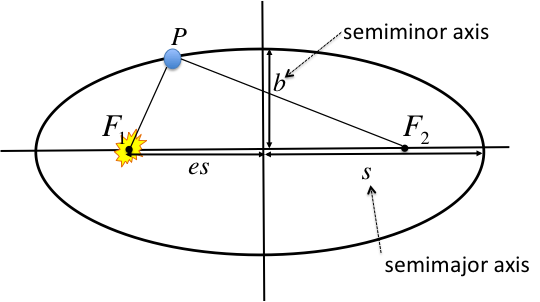

$F_{1}P+F_{2}P=2s$

$e$ is the eccentricity and $0\lt e\lt 1$.

The eccentricity is the deviation of the orbit from circular, Earth's eccentricity is 0.017, which is not very much.

### Eccentricity

The following video shows how varying the eccentricity of an ellipse changes the shape.

Credit: [Prof. Zingale](https://zingale.github.io/astro_animations/)

```python
from IPython.display import HTML

HTML("""
<div align="middle">
<video width="80%" controls>
      <source src="Videos/eccentricity.mp4 " type="video/mp4">
</video></div>""")
```

[video not shown]

### Orbtis of Planets

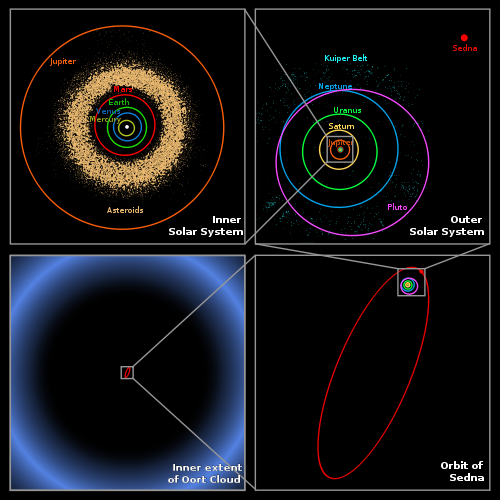

The orbits of most of the planets have low eccentricity. Pluto is more eccentric than the others…but it is also no longer a planet, mainly because we have found many more objects out there which are better described as [dwarf planets](https://en.wikipedia.org/wiki/Dwarf_planet). Sedna is the most distant known object in the solar system and is about two-thirds the size of Pluto..and as you can see has a very long and eccentric orbit.

### Kepler's Second Law

The line joining a planet and the Sun sweeps out equal areas during equal intervals of time.

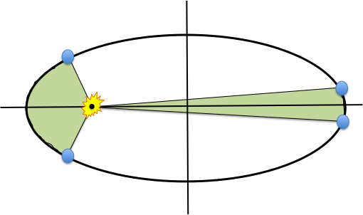

This means that planets move faster when they are closer to the sun.

```python
from IPython.display import HTML

HTML("""
<div align="middle">
<video width="80%" controls>
      <source src="Videos/second_law.mp4 " type="video/mp4">
</video></div>""")
```

[video not shown]

### Comets - High Eccentricy Orbits

[figure not shown]

### Kepler's Thrid Law

The square of the orbital period of a planet is directly proportional to the cube of the semi-major axis of it's orbit

So if two planets have semimajor axes $s_{1}$ and $s_{2}$ then their periods can be related to each other via the relation

$\large (\frac{T_{1}}{T_{2}})^{2}=(\frac{s_{1}}{s_{2}})^{3}$

It follows that $\frac{s^{3}}{T^{2}}$ should be the same for each planet.

### Derivation of Kepler's Third Law

We will derive Kepler's Third Law for the special case of a circular orbit.

We consider only the force between the sun and the planet (ie. we ignore the force from the other planets.)

$G\frac{m_{p}M_{s}}{r_{p}^{2}}=m_{p}\frac{v_{p}^2}{r_{p}}$

$\large v_{p}=\frac{2\pi r_{p}}{T_{p}}$

$G\frac{m_{p}M_{s}}{r_{p}^{2}}=m_{p}\frac{4\pi^2 r_{p}}{T_{p}^2}$

$\large \frac{T_{p}^2}{r_{p}^3}=\frac{4\pi^{2}}{GM_{s}}$

$T_{p}^2=\frac{4\pi^{2}}{GM_{s}}r_{p}^3$

So for a circular orbit we have shown that the square of the orbital period of a planet is directly proportional to the cube of the semi-major axis of it's orbit ($r_{p}$ for a circle).

### A servant with two masters - the Moon

The Sun's gravitational pull on the Moon is actually more than twice that of the Earth, and it's path around the Sun is not all that different to the Earth. However, its orbit around the Earth, is subject to several pertubations.